# Exploring UK Biobank phenotypes with NOR

The UK Biobank contains a vast array of phenotypes from over 500,000 individuals. This notebook will show how to browse through these phenotypes using NOR and display the phenotypes within the notebook using [ggplot](https://ggplot2.tidyverse.org/). First, we have to set up our libraries to connect to the Query API and load the graphing tools.

```r
source("lib/setup.R")
source("lib/graphs.R")

library(lubridate)
library(scales)

install.packages("viridis")
library(viridis)
```

## Dates of measurements

```r
# This will give us three columns: value, visit_id, and allCount

biobank.visits <- query("
nor -h UKBB/phenotypes/fields/53.tsv
    | GROUP -count -gc value,visit_id
    | RENAME value date
    | RENAME visit_id visit
    | RENAME allCount n
    | REPLACE visit IF(visit=0,'First Assessment',IF(visit=1,'First Repeat Assessment','Imaging Visit'))
") %>%
  mutate(date = floor_date(as.Date(date), "month")) %>%
  group_by(visit,date) %>%
  summarize(n=sum(n)) %>%
  ungroup()

# Summary data for the 3 labels
biobank.visit.summary <-
  biobank.visits %>%
  group_by(., visit) %>%
  summarize(n = sum(n), start = date[3])
```

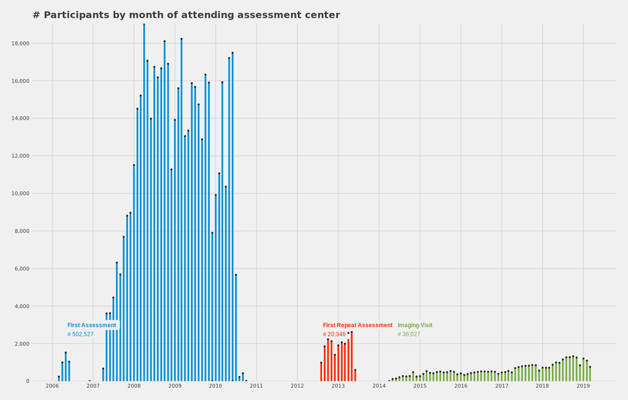

```r
options(repr.plot.width = 11)
biobank.visits %>%
    ggplot() +
    geom_segment(aes(x = date, y = 0, xend = date, yend = n, color = visit), size = 1) +
    geom_label(aes(x = start, y = 3e3, label = visit, color = visit), data = biobank.visit.summary, size = 2.5, fontface = "bold", hjust = 0, fill = "#f0f0f0", label.size = 0) +
    geom_label(aes(x = start, y = 2.5e3, label = paste("#",comma(n)), color = visit), data = biobank.visit.summary, size = 2.5, hjust = 0, fill = "#f0f0f0", label.size = 0) +
    geom_point(aes(x = date, y = n), size = .5, color = "#202020") +
    scale_x_date(breaks = scales::date_breaks("year"), labels = scales::date_format("%Y")) +
    scale_y_continuous(expand = c(0,0), breaks = pretty_breaks(10), labels = comma) +
    scale_color_fivethirtyeight(guide = F) +
    theme_fivethirtyeight(8, "Roboto Condensed") +
    labs(title = "# Participants by month of attending assessment center")
```

## Ethnicities in the UK Biobank dataset

The following section takes information from datacode 21000, which contains ethnic background information for 501,602 participants. The NOR query groups the ethnicities and returns the number for each, then maps the code for the ethnicity to its value and sorts in descending order. This is then displayed using ggplot, labelling each response with the number of cases in each.

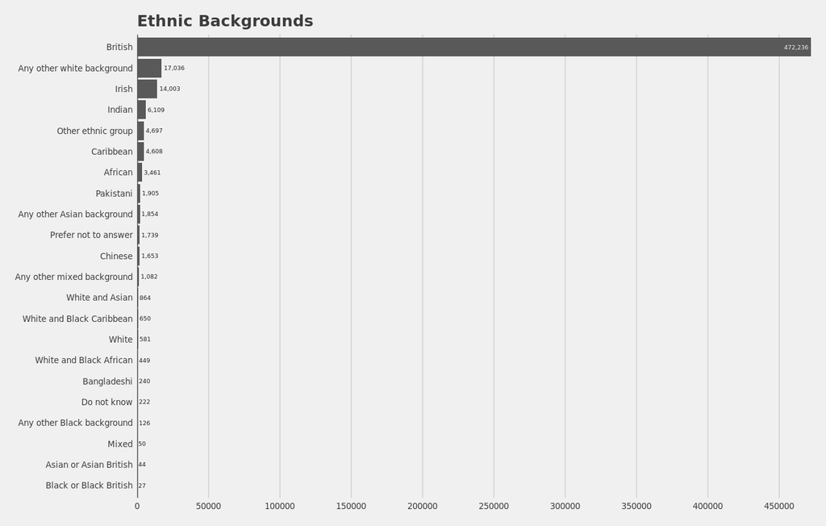

```r
biobank.ethnicities <- query("
    nor -h UKBB/phenotypes/fields/21000.tsv
        | group -gc value -count
        | RENAME value coding
        | MAP UKBB/phenotypes/datacodes-by-field/21000.tsv -c coding
        | SELECT allCount,meaning
        | SORT -c allCount:nr
        | RENAME meaning ethnicity
        | RENAME allCount n
")
options(repr.plot.width = 11)
biobank.ethnicities %>%
  mutate(ethnic_background = fct_reorder(ethnicity, n)) %>%
  ggplot(aes(ethnic_background, n)) +
  geom_hline(yintercept = 0, size = 0.5) +
  geom_col() +
  geom_text(aes(label = comma(n), hjust = ifelse(n < 100e3,-.1,1.1), color = ifelse(n < 100e3,"in","out")),
            family = "Roboto Condensed", size = 2) +
  scale_y_continuous(expand = c(0,0), breaks = pretty_breaks(15)) +
  scale_color_manual(values = c("out" = "#f0f0f0", "in" = "#202020"), guide = F) +
  coord_flip() +
  theme_fivethirtyeight(10, "Roboto Condensed") +
  theme(panel.grid.major.y = element_blank()) +
  labs(title = "Ethnic Backgrounds")
```

## Age distribution by gender

In the next section, we are comparing the age of the participant when they first came to an assessment centre to their age today. If the participant has died in the meantime, we note the age when that happened. Finally, we calculate the means and medians for these data sets and plot them according to their reported gender.

The following table shows the first few entries from the data once it has been prepared in NOR. Note that the method used here is fallible since we are creating separate data sets for each of the variables and then left-joining them using the `MAP` command. However, this can be a problem if the left source in the join does not have data for that PN. In that case, we could miss some data. Another, more robust, method is described below.

```r
# The definitions show the phenotype tables that we will be working from (based on the UKBB data fields)
mydefs <- "def #sex# = 31;
def #year_of_birth# = 34;
def #age_when_attended_assessment_centre# = 21003;
def #age_at_death# = 40007;
"

query <- gor_create(
    defs = mydefs,
    `##birth_year##` = "nor -h UKBB/phenotypes/fields/#year_of_birth#.tsv
 | SELECT PN,value
 | RENAME value year_of_birth",
    `##age_start##` = "nor -h UKBB/phenotypes/fields/#age_when_attended_assessment_centre#.tsv
 | WHERE visit_id = 0
 | RENAME value age_start
 | SELECT PN,age_start",
    `##age_death##` = "nor -h UKBB/phenotypes/fields/#age_at_death#.tsv
 | CALC age_death floor(value)
 | SELECT PN,age_death
 | DISTINCT",
    conn = conn)

biobank.age <- query("nor -h UKBB/phenotypes/fields/#sex#.tsv
| MAP UKBB/phenotypes/datacodes-by-field/#sex#.tsv -c value | SELECT PN,meaning | WHERE meaning IN ('Female','Male')
| RENAME meaning sex
| MAP -c PN <(nor [##birth_year##])
| MAP -c PN <(nor [##age_start##])
| MAP -c PN -m '' <(nor [##age_death##])
| CALC age_now if(age_death > 0,age_death,int(date('yyyy'))-year_of_birth)
| HIDE age_death,year_of_birth")

head(biobank.age)
```

A tibble: 6 × 4

| PN <int> | sex <chr> | age_start <int> | age_now <int> |
| --- | --- | --- | --- |
| 2480635 | Female | 46 | 56 |
| 1395046 | Female | 52 | 64 |
| 2837706 | Male | 67 | 72 |
| 3790069 | Female | 58 | 68 |
| 3628535 | Male | 57 | 69 |
| 1785154 | Female | 55 | 65 |

Another way of doing this would be to use the NOR dictionary table, which can then filter the information based on tags that we can set for the phenotypes we are interested in. This can then be combined into an aggregate and pivoted, which ensures that none of the PNs are lost from the dataset.

```r
query <- gor_create(
    `##fields##` = "
    nor -h UKBB/phenotypes/meta/field_titles.tsv
        | where field_id in ('31','34','21003','40007')
        | select field_title",
    `##colnames##` = "
    nor [##fields##]
        | calc colname replace(fsvmap(field_title,1,\"if(x in ('-','(',')','/',' '),'',x)\",''),'__','_')
        | select colname",
    `##aggregate##` = "
    nor UKBB/phenotypes/fields.nord -s phenotype -ff [##fields##]
        | WHERE visit_id = 0
        | map -h -m '#empty#' -c  phenotype,value <(nor -h UKBB/phenotypes/meta/field_encoding_lookup.tsv)
        | replace value if(meaning = '#empty#',value,meaning)
        | group -gc pn,phenotype -lis -sc value",
    `##fieldpivot##` = "nor [##aggregate##] | sort -c PN
  | pivot phenotype -ordered -gc PN -vf [##fields##] -vp [##colnames##] -e 0
    | rename (.*)_value #{1}",
    conn = conn)

biobank.age <- query("
    nor [##fieldpivot##]
        | RENAME sex_lis sex
        | RENAME age_when_attended_assessment_centre_lis age_start
        | REPLACE age_at_death_lis FLOOR(age_at_death_lis)
        | RENAME age_at_death_lis age_death
        | RENAME year_of_birth_34_lis year_of_birth
        | REPLACE year_of_birth int(year_of_birth)
        | CALC age_now if(age_death > 0,age_death,int(date('yyyy'))-year_of_birth)
        | COLUMNSORT PN,sex,year_of_birth,age_start,age_death,age_now
        | HIDE age_death,year_of_birth")

head(biobank.age)
```

A tibble: 6 × 4

| PN <int> | sex <chr> | age_start <int> | age_now <int> |
| --- | --- | --- | --- |
| 6000902 | Male | 66 | 77 |
| 6000915 | Male | 46 | 56 |
| 6000927 | Female | 52 | 63 |
| 6000939 | Female | 59 | 69 |
| 6000940 | Male | 40 | 51 |
| 6000953 | Male | 62 | 73 |

We then use R to group the variables and summarize to get the mean and median age for both genders.

```r
biobank.age.summary <-
  biobank.age %>%
  gather(age_variable, age, -PN, -sex) %>%
  group_by(sex, age_variable) %>%
  summarize(mean = mean(age),
            median = median(age))
biobank.age.summary
```

A grouped_df: 4 × 4

| sex <chr> | age_variable <chr> | mean <dbl> | median <dbl> |
| --- | --- | --- | --- |
| Female | age_now | 67.10690 | 68 |
| Female | age_start | 56.34793 | 57 |
| Male | age_now | 67.36571 | 69 |
| Male | age_start | 56.74393 | 58 |

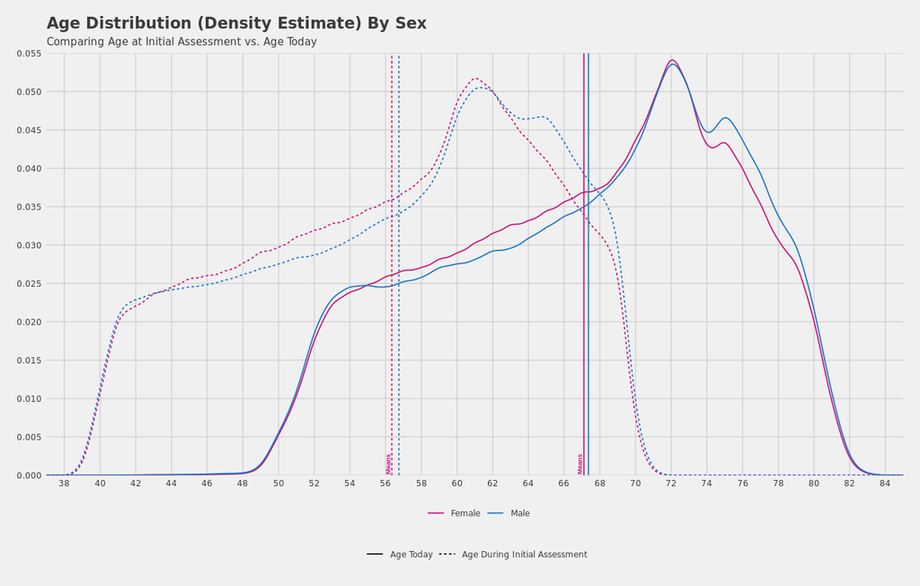

```r
# Age distribution by sex

biobank.age %>%
  gather(age_variable, age, -PN, -sex) %>%
  ggplot(aes(age, color = sex, lty = age_variable)) +
  stat_density(size = 0.5, geom = "line", position = position_dodge()) +
  geom_vline(aes(xintercept = mean, lty = age_variable, color = sex), data = biobank.age.summary, show.legend = F) +
  theme_fivethirtyeight(9, "Roboto") +
  geom_text(aes(x = mean-0.1, y = 0.0001, label = "Means"),
            data = biobank.age.summary[c(1,2),], angle = 90, hjust = 0, vjust = 0, fontface = "bold", size = 2, show.legend = F) +
  scale_y_continuous(breaks = scales::pretty_breaks(10), expand = c(0,0), limits = c(0,0.055)) +
  scale_x_continuous(breaks = scales::pretty_breaks(20), expand = c(0,0)) +
  scale_color_manual(values = c("Female" = "deeppink3", "Male" = "dodgerblue3")) +
  scale_linetype(labels = c("age_now" = "Age Today", "age_start" = "Age During Initial Assessment")) +
  labs(color = "", lty = "", title = "Age Distribution (Density Estimate) By Sex", subtitle = "Comparing Age at Initial Assessment vs. Age Today")
```

The following query is a bit more heavy for the Query API to work on. We are looking for all fields that start with "age_", which is a pattern that occurs fairly often in the dataset. This is meant to illustrate some of the use cases of the phenotype catalog where a user may wish to search for such a pattern.

```r
query <- gor_create(
    `##fields##` = "nor -h UKBB/phenotypes/meta/field_titles.tsv | WHERE field_title like 'age_*' | SELECT field_title",
    `##colnames##` = "nor [##fields##] | calc colname replace(fsvmap(field_title,1,\"if(x in ('-','(',')','/',' '),'',x)\",''),'__','_') | select colname",
    `##aggregate##` = "nor UKBB/phenotypes/fields.nord -s phenotype -ff [##fields##]
        | WHERE visit_id = 0
        | map -h -m '#empty#' -c  phenotype,value <(nor -h UKBB/phenotypes/meta/field_encoding_lookup.tsv)
        | replace value if(meaning = '#empty#',value,meaning)
        | group -gc pn,phenotype -lis -sc value
        | rename lis_value value",
    `##fieldpivot##` = "nor [##aggregate##] | sort -c PN
        | pivot phenotype -ordered -gc PN -vf [##fields##] -vp [##colnames##] -e 0
        | rename (.*)_value #{1}",
    conn = conn)

biobank.all.age.vars <- query("nor [##aggregate##]")
```

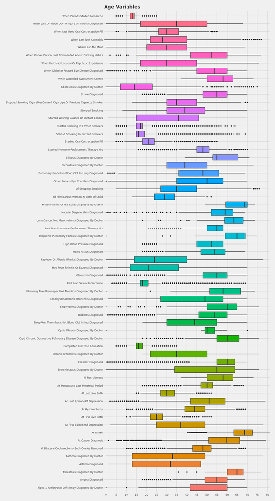

```r
options(repr.plot.width = 11, repr.plot.height = 15)
biobank.all.age.vars %>%
  filter(!is.na(value)) %>%
  mutate(value = as.numeric(value), columnname = fct_reorder(phenotype, -value, mean)) %>%
  ggplot(aes(x = phenotype, y = value, fill = phenotype)) +
  theme_fivethirtyeight(9, "Roboto Condensed") +
  geom_boxplot(outlier.size = 1, outlier.color = "#202020") +
  coord_flip() +
  scale_x_discrete(labels = function(x) x %>% str_replace("age","") %>% str_replace_all("_"," ") %>% str_to_title() ) +
  scale_y_continuous(breaks = pretty_breaks(20), expand = c(0,0)) +
  scale_fill_discrete(guide = F) +
  labs(title = "Age Variables")
```

In a similar case, we are using the pattern "diagnosed_by_doctor" to show the ages when patients were diagnosed with various illnesses. Here we are using a "violin" graph which uses kernel density estimation to better visualize the approximated underlying distributions.

```r
query <- gor_create(
    `##fields##` = "nor -h UKBB/phenotypes/meta/field_titles.tsv | WHERE field_title like '*diagnosed_by_doctor*' | SELECT field_title",
    `##colnames##` = "nor [##fields##] | calc colname replace(fsvmap(field_title,1,\"if(x in ('-','(',')','/',' '),'',x)\",''),'__','_') | select colname",
    `##aggregate##` = "nor UKBB/phenotypes/fields.nord -s phenotype -ff [##fields##]
        | WHERE visit_id = 0
        | map -h -m '#empty#' -c  phenotype,value <(nor -h UKBB/phenotypes/meta/field_encoding_lookup.tsv)
        | replace value if(meaning = '#empty#',value,meaning)
        | group -gc pn,phenotype -lis -sc value
        | rename lis_value value",
    `##fieldpivot##` = "nor [##aggregate##] | sort -c PN
        | pivot phenotype -ordered -gc PN -vf [##fields##] -vp [##colnames##] -e 0
        | rename (.*)_value #{1}",
    conn = conn)

biobank.all.diagnoses <- query("nor [##aggregate##]")
```

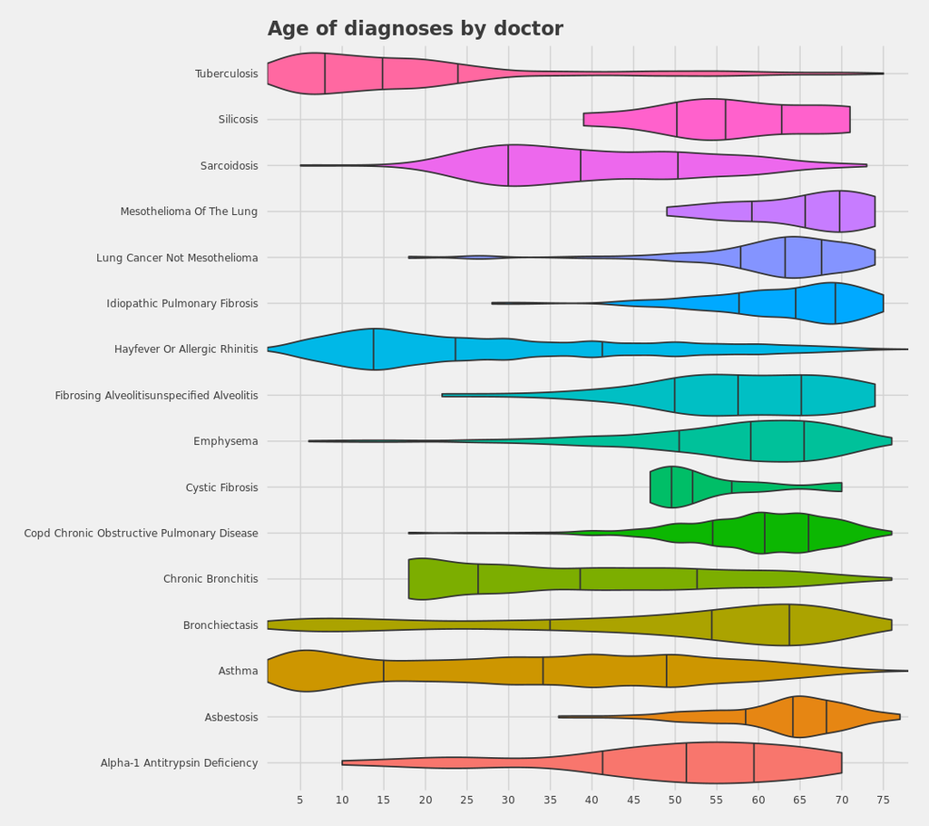

```r
options(repr.plot.width = 9, repr.plot.height = 8)
biobank.all.diagnoses %>%
  mutate(value = as.numeric(value), columnname = fct_reorder(phenotype, -value, mean)) %>%
  filter(value > 0 ) %>%
  ggplot(aes(x = phenotype, y = value, fill = phenotype)) +
  theme_fivethirtyeight(9, "Roboto") +
  geom_violin(scale = "width", draw_quantiles = c(0.25,0.5,0.75)) +
  coord_flip() +
  scale_x_discrete(labels = function(x) x %>% str_replace("age","") %>% str_replace("diagnosed_by_doctor","")%>% str_replace_all("_"," ") %>% str_to_title() ) +
  scale_y_continuous(breaks = pretty_breaks(20), expand = c(0,0)) +
  scale_fill_discrete(guide = F) +
  labs(title = "Age of diagnoses by doctor")
```

Finally, we can take the standing height, weight and BMI data for a sample (20000) of patients and plot a graph showing the distribution of values across this sample.

```r
query <- gor_create(
    `##fields##` = "nor -h UKBB/phenotypes/meta/field_titles.tsv | WHERE field_title in ('weight_21002','standing_height','body_mass_index_bmi_21001','sex') | SELECT field_title",
    `##colnames##` = "nor [##fields##] | calc colname replace(fsvmap(field_title,1,\"if(x in ('-','(',')','/',' '),'',x)\",''),'__','_') | select colname",
    `##aggregate##` = "nor UKBB/phenotypes/fields.nord -s phenotype -ff [##fields##]
        | WHERE visit_id = 0
        | map -h -m '#empty#' -c  phenotype,value <(nor -h UKBB/phenotypes/meta/field_encoding_lookup.tsv)
        | REPLACE value if(meaning = '#empty#',value,meaning)
        | group -gc pn,phenotype -lis -sc value",
    `##fieldpivot##` = "nor [##aggregate##] | sort -c PN
        | pivot phenotype -ordered -gc PN -vf [##fields##] -vp [##colnames##] -e NA
        | rename (.*)_value #{1}",
    conn = conn)

biobank.weight.height <- query("nor [##fieldpivot##]")
head(biobank.weight.height)
```

A tibble: 6 × 5

| PN <int> | body_mass_index_bmi_21001_lis <dbl> | weight_21002_lis <dbl> | sex_lis <chr> | standing_height_lis <dbl> |
| --- | --- | --- | --- | --- |
| 6000902 | 29.0612 | 89.0 | Male | 175 |
| 6000915 | 26.6090 | 76.9 | Male | 170 |
| 6000927 | 24.9425 | 60.7 | Female | 156 |
| 6000939 | 26.8977 | 68.0 | Female | 159 |
| 6000940 | 26.9061 | 82.4 | Male | 175 |
| 6000953 | 29.0785 | 91.1 | Male | 177 |

```r
query <- gor_create(
    defs = "def #phenos# = weight_21002,standing_height,body_mass_index_bmi_21001,sex",
     `##aggregate##` = "nor UKBB/phenotypes/fields.nord -s phenotype -f #phenos#
        | ATMAX visit_id -gc PN,phenotype
        | map -h -m '#empty#' -c phenotype,value <(nor -h UKBB/phenotypes/meta/field_encoding_lookup.tsv)
        | REPLACE value if(meaning = '#empty#',value,meaning)
        | hide meaning,visit_id,index_id",
    `##fieldpivot##` = "nor [##aggregate##] | sort -c PN
        | pivot phenotype -ordered -gc PN -v #phenos# -e NA
        | rename (.*)_value #{1}",
    conn = conn)

biobank.weight.height <- query("nor [##fieldpivot##]")
head(biobank.weight.height)
```

A tibble: 6 × 5

| PN <int> | weight_21002 <dbl> | standing_height <dbl> | body_mass_index_bmi_21001 <dbl> | sex <chr> |
| --- | --- | --- | --- | --- |
| 6000902 | 89.0 | 175 | 29.0612 | Male |
| 6000915 | 76.9 | 170 | 26.6090 | Male |
| 6000927 | 60.7 | 156 | 24.9425 | Female |
| 6000939 | 68.0 | 159 | 26.8977 | Female |
| 6000940 | 82.4 | 175 | 26.9061 | Male |
| 6000953 | 91.1 | 177 | 29.0785 | Male |

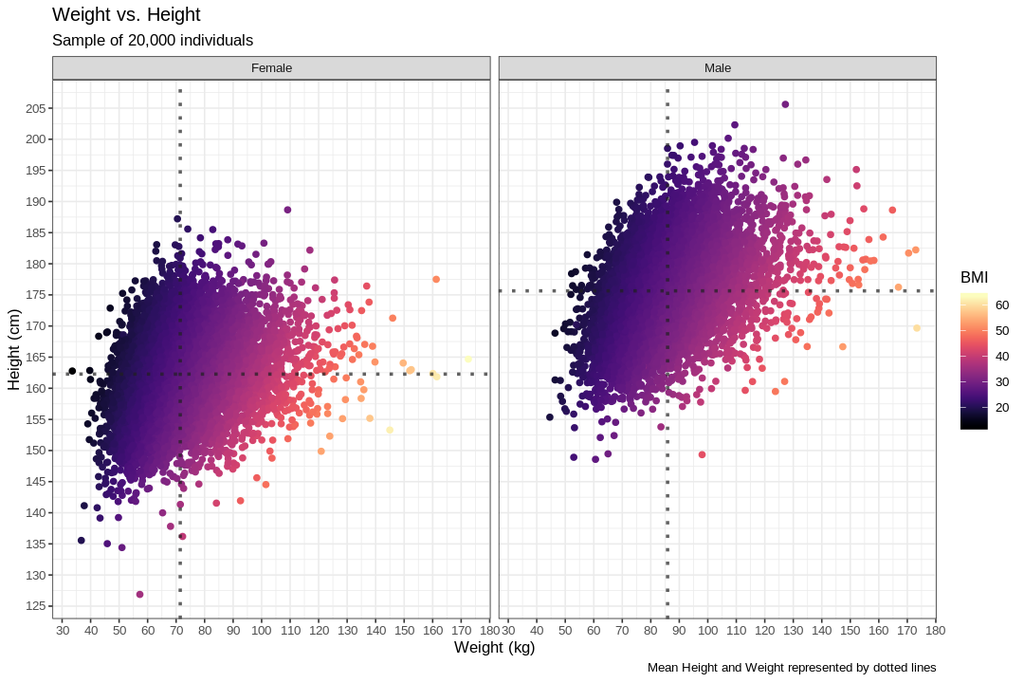

```r
options(repr.plot.width = 9, repr.plot.height = 6)
biobank.weight.height %>%
  sample_n(20000) %>% {
    sex.means <-
      group_by(., sex) %>%
      summarize(height = mean(standing_height, na.rm = T),
                weight = mean(weight_21002, na.rm = T))

    ggplot(., aes(x = weight_21002, y = standing_height, color = body_mass_index_bmi_21001)) +
      geom_jitter(height = .5, na.rm = T) +
      geom_vline(aes(xintercept = weight), color = "#202020", lty = 3, alpha = .7, size = 1, data = sex.means) +
      geom_hline(aes(yintercept = height), color = "#202020", lty = 3, alpha = .7, size = 1, data = sex.means) +
      viridis::scale_color_viridis(option = "magma")  +
      #theme_fivethirtyeight(9, "Roboto Condensed") +
      labs(color = "BMI", x = "Weight (kg)", y = "Height (cm)", title = "Weight vs. Height", subtitle = "Sample of 20,000 individuals",
           caption = "Mean Height and Weight represented by dotted lines") +
      scale_x_continuous(breaks = pretty_breaks(15)) +
      scale_y_continuous(breaks = pretty_breaks(20)) +
      facet_wrap(~sex)
  }
```

## Blood pressure measurements